# Ford GoBike System

## by Mustafa Ahmed

## Investigation Overview

Our goal is to find out how gender, user type and weekday affect number of trips and duration.

## Dataset Overview

The dataset have 10 columns with 174952 observations. Our main focus will be on (duration_min, user_type, member_gender, age).

## Duration and Age

This plot shows that age has a great effect on trip duration. As users get older (maybe after 45), they have shorter trips and this is normal.

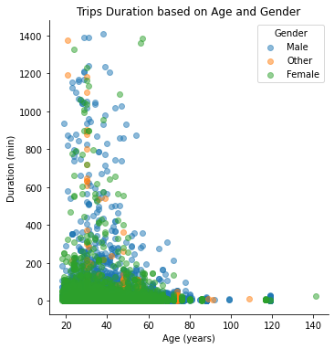

## Gender: (Duration, Number of Users)

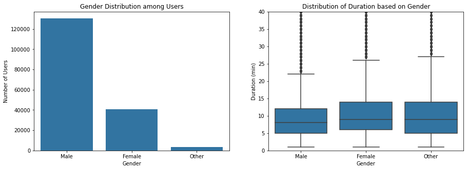

## Weekday: (Duration, Number of Users)

Left side plot shows that number of trips increase on weekdays and decrease on weekends (Saturday and Sunday) and that is normal. Interestingly, Duration is almost stable throuhgh the whole week with slight longer trips on weekends!

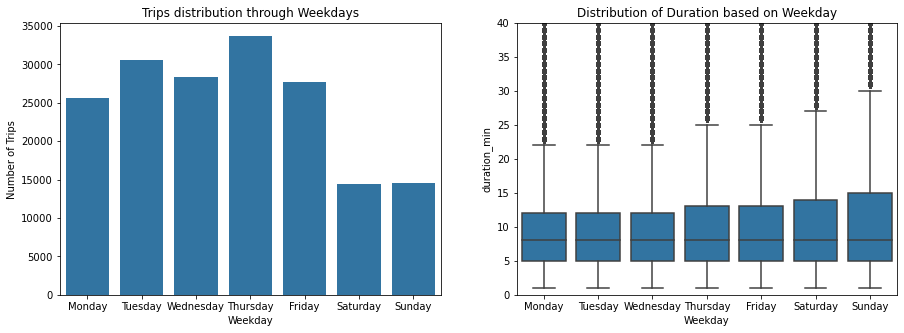

## User Type: (Duration, Number of Trips)

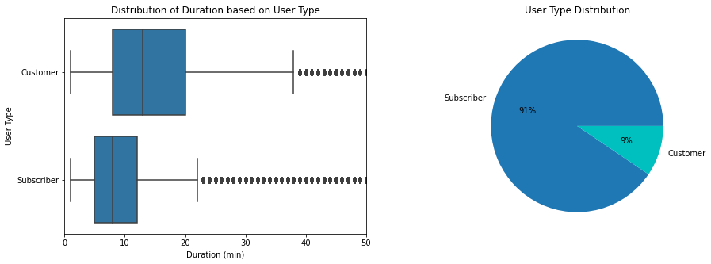

## Conclusion

After our analysis, we can say that number of users/trips can be affected by factors such as (weekday, user type, and gender). On other hand, trips duration mostly affected by age.